# Tarea 11_Ricardo Zamora Mennigke_Mineria de Datos I

Ricardo Zamora Mennigke

6/3/2020

#Tarea 11 #Mineria de Datos I #Ricardo Zamora Mennigke

```r
library(tidyverse)
```

```r
library(ggplot2)
library(dplyr)
library(glue)
library(scales)
library(xgboost)
library(randomForest)
```

Ejercicio 1: [30 puntos] Para esta pregunta tambi´en usaremos los datos tumores.csv.

1. El objetivo de este ejercicio es calibrar el m´etodo de ADA para esta Tabla de Datos. Aqu´ı interesa predecir en la variable tipo. Usando los paquetes snow y traineR programe en paralelo 5 Validaciones Cruzadas con 10 grupos calibrando el modelo de acuerdo con los tres tipos de algoritmos que permite, discrete, real y gentle. Para medir la calidad de m´etodo sume la cantidad de 1’s detectados en los diferentes grupos. Luego grafique las 5 iteraciones para los tres algoritmos en el mismo gr´afico. ¿Se puede determinar con claridad cu´al algoritmo es el mejor? Para generar los modelos predictivos use las siguientes instrucciones:

```r
setwd("C:/Users/rzamoram/Documents/Machine Learning/Mineria de Datos I/Clase2")
datos<-read.csv("tumores.csv",dec='.',header=T)
head(datos)
```

```
##   imagen     media  varianza desviacion.estandar  entropia asimetria  kurtosis
## 1 Image1 23.448517 2538.9856            50.38835 0.6511741  1.984202  5.421042
## 2 Image2  4.398331  834.8530            28.89382 0.9535317  6.495203 43.349355
## 3 Image3  3.244263  642.0592            25.33889 0.9660645  7.772860 61.756034
## 4 Image4  8.511353 1126.2142            33.55911 0.8687651  3.763142 15.107579
## 5 Image5 21.000793 2235.3170            47.27914 0.6847244  1.936029  4.722343
## 6 Image7 11.350555  998.9722            31.60652 0.7611065  2.533920  7.394586
##   contraste   energia       asm homogeneidad disiminitud correlacion      psnr
## 1 181.46771 0.7815569 0.6108312    0.8470333   2.7654114   0.9685761  97.97463
## 2  76.74589 0.9727695 0.9462805    0.9807616   0.5486053   0.9597505 110.34660
## 3  81.75241 0.9801609 0.9607154    0.9850659   0.5404114   0.9442587 112.26630
## 4 362.29121 0.9217862 0.8496899    0.9492953   2.7657252   0.8590271 101.95579
## 5 312.43923 0.8041836 0.6467113    0.8803008   3.0066597   0.9385719  97.63987
## 6 303.94798 0.8542768 0.7297889    0.9023554   3.4405509   0.8664795  99.20658
##        ssim         mse        dc tipo
## 1 0.7770111 0.171163194 0.3039887    1
## 2 0.9779528 0.009913194 0.8390189    1
## 3 0.9853620 0.006371528 0.8497749    1
## 4 0.8810152 0.068437500 0.0000000    0
## 5 0.7663084 0.184878472 0.0000000    0
## 6 0.7948807 0.128888889 0.0000000    0
```

```r
library(caret)
```

```r
datos$tipo <- factor(datos$tipo,ordered = TRUE)
datos$imagen <- as.integer(datos$imagen,ordered = TRUE)
summary(datos)
```

```
##      imagen           media              varianza        desviacion.estandar
##  Min.   :   1.0   Min.   : 0.001541   Min.   :   0.156   Min.   : 0.3945
##  1st Qu.: 319.5   1st Qu.: 0.381950   1st Qu.:  58.557   1st Qu.: 7.6523
##  Median : 638.0   Median : 1.826401   Median : 280.429   Median :16.7460
##  Mean   : 638.0   Mean   : 4.029659   Mean   : 486.384   Mean   :18.3179
##  3rd Qu.: 956.5   3rd Qu.: 4.974586   3rd Qu.: 707.677   3rd Qu.:26.6022
##  Max.   :1275.0   Max.   :31.031021   Max.   :3345.854   Max.   :57.8434
##     entropia        asimetria          kurtosis          contraste
##  Min.   :0.5307   Min.   :  1.219   Min.   :    2.50   Min.   :  0.3557
##  1st Qu.:0.9326   1st Qu.:  5.437   1st Qu.:   30.57   1st Qu.: 20.7866
##  Median :0.9757   Median :  9.377   Median :   88.95   Median : 50.4217
##  Mean   :0.9344   Mean   : 16.996   Mean   :  742.22   Mean   : 75.0515
##  3rd Qu.:0.9943   3rd Qu.: 20.320   3rd Qu.:  415.83   3rd Qu.: 97.1238
##  Max.   :0.9999   Max.   :255.995   Max.   :65534.24   Max.   :743.3681
##     energia            asm          homogeneidad     disiminitud
##  Min.   :0.6959   Min.   :0.4843   Min.   :0.8111   Min.   :0.003522
##  1st Qu.:0.9603   1st Qu.:0.9223   1st Qu.:0.9730   1st Qu.:0.150540
##  Median :0.9858   Median :0.9718   Median :0.9895   Median :0.415167
##  Mean   :0.9600   Mean   :0.9257   Mean   :0.9739   Mean   :0.704138
##  3rd Qu.:0.9967   3rd Qu.:0.9934   3rd Qu.:0.9975   3rd Qu.:0.821914
##  Max.   :1.0000   Max.   :0.9999   Max.   :1.0000   Max.   :5.604428
##   correlacion              psnr             ssim             mse
##  Min.   :-0.0000349   Min.   : 53.38   Min.   :0.6760   Min.   :0.0002257
##  1st Qu.: 0.8308350   1st Qu.: 62.04   1st Qu.:0.9369   1st Qu.:0.0118142
##  Median : 0.9001476   Median : 64.94   Median :0.9612   Median :0.0235417
##  Mean   : 0.8650773   Mean   : 68.90   Mean   :0.9395   Mean   :0.0424071
##  3rd Qu.: 0.9419782   3rd Qu.: 68.75   3rd Qu.:0.9773   3rd Qu.:0.0440017
##  Max.   : 0.9901755   Max.   :123.29   Max.   :0.9993   Max.   :0.2986979
##        dc          tipo
##  Min.   :0.00000   0:  97
##  1st Qu.:0.08947   1:1178
##  Median :0.36098
##  Mean   :0.38858
##  3rd Qu.:0.65969
##  Max.   :0.95797
```

```r
str(datos)
```

```
## 'data.frame':    1275 obs. of  18 variables:
##  $ imagen             : int  1 614 698 790 871 1030 1108 1194 2 85 ...
##  $ media              : num  23.45 4.4 3.24 8.51 21 ...
##  $ varianza           : num  2539 835 642 1126 2235 ...
##  $ desviacion.estandar: num  50.4 28.9 25.3 33.6 47.3 ...
##  $ entropia           : num  0.651 0.954 0.966 0.869 0.685 ...
##  $ asimetria          : num  1.98 6.5 7.77 3.76 1.94 ...
##  $ kurtosis           : num  5.42 43.35 61.76 15.11 4.72 ...
##  $ contraste          : num  181.5 76.7 81.8 362.3 312.4 ...
##  $ energia            : num  0.782 0.973 0.98 0.922 0.804 ...
##  $ asm                : num  0.611 0.946 0.961 0.85 0.647 ...
##  $ homogeneidad       : num  0.847 0.981 0.985 0.949 0.88 ...
##  $ disiminitud        : num  2.765 0.549 0.54 2.766 3.007 ...
##  $ correlacion        : num  0.969 0.96 0.944 0.859 0.939 ...
##  $ psnr               : num  98 110.3 112.3 102 97.6 ...
##  $ ssim               : num  0.777 0.978 0.985 0.881 0.766 ...
##  $ mse                : num  0.17116 0.00991 0.00637 0.06844 0.18488 ...
##  $ dc                 : num  0.304 0.839 0.85 0 0 ...
##  $ tipo               : Ord.factor w/ 2 levels "0"<"1": 2 2 2 1 1 1 2 2 2 2 ...
```

```r
dim(datos)
```

```
## [1] 1275   18
```

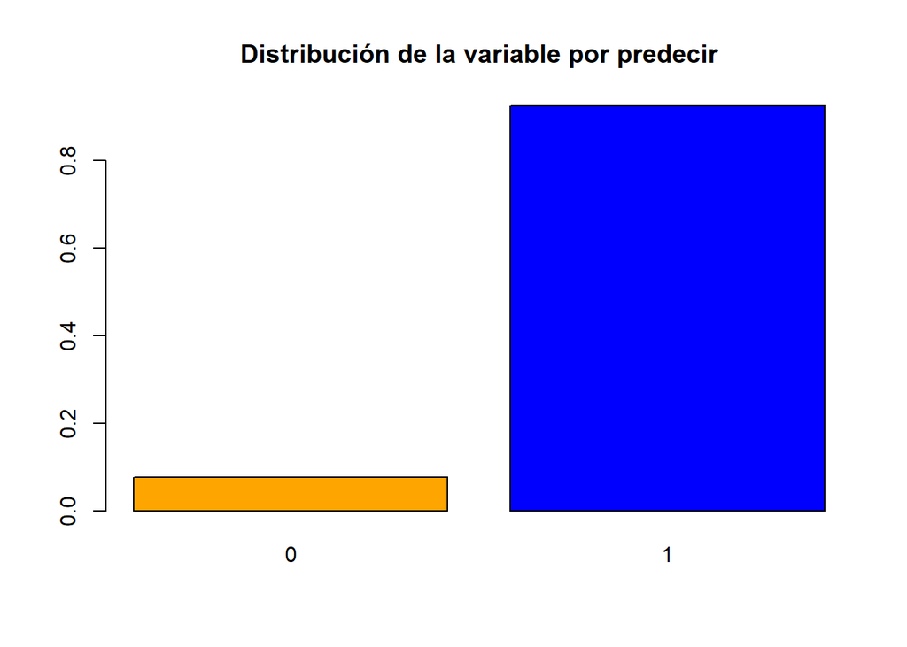

```r
barplot(prop.table(table(datos$tipo)),col=c("orange","blue","green"),main="Distribución de la variable por predecir")
```

Ejercicio desbalanceado

1. El objetivo de este ejercicio es calibrar el m´etodo de ADA para esta Tabla de Datos. Aqu´ı interesa predecir en la variable tipo. Para esto genere 5 Validaciones Cruzadas con 10 grupos calibrando el modelo de acuerdo con los tres tipos de algoritmos que permite, discrete, real y gentle. Para medir la calidad de m´etodo sume la cantidad de 1’s detectados en los diferentes grupos. Luego grafique las 5 iteraciones para los tres algoritmos en el mismo gr´afico. ¿Se puede determinar con claridad cu´al algoritmo es el mejor? Para generar los modelos predictivos use las siguientes instrucciones:

```r
library(traineR)
library(snow)
library(caret)


clp <- makeCluster(5, type = "SOCK")


clusterExport(clp, "datos")
ignore <- clusterEvalQ(clp, {
      library(traineR)

      ejecutar.prediccion <- function(datos, formula, muestra,metodo, ...) {
        ttesting <- datos[muestra, ]
        taprendizaje <- datos[-muestra, ]
        modelo <- metodo(formula, data = taprendizaje, ...)
        prediccion <- predict(modelo, ttesting, type = "class")
        MC <- confusion.matrix(ttesting, prediccion)
        return(MC)
      }
      return(NULL)
})

numero.filas <- nrow(datos)
cantidad.grupos <- 10
cantidad.validacion.cruzada <- 5
algoritmos <- c("discrete", "real", "gentle")

deteccion.no.discrete <- c()
deteccion.no.real <- c()
deteccion.no.gentle <- c()


tiempo.paralelo <- Sys.time()

for(i in 1:cantidad.validacion.cruzada) {
  grupos <- createFolds(1:numero.filas, cantidad.grupos)
  no.discrete <- 0
  no.real <- 0
  no.gentle <- 0

  for(k in 1:cantidad.grupos) {
    muestra <- grupos[[k]]

    clusterExport(clp, "muestra")

    resultado <- clusterApply(clp, algoritmos, function(pkernels) {
      MC <- ejecutar.prediccion(datos, tipo ~ .,muestra, train.ada , iter=80,nu=1)
      no.val <- MC[2, 2] ####PARA DETECTAR 1'S DE CANCER
      valores <- list(Tipo = pkernels, Resultado = no.val)
      valores
    })

    for (j in 1:length(algoritmos)) {
      if (resultado[[j]][[1]] == "discrete")
         no.discrete <- no.discrete + resultado[[j]][[2]]
      else if (resultado[[j]][[1]] == "real")
         no.real <- no.real + resultado[[j]][[2]]
      else if (resultado[[j]][[1]] == "gentle")
         no.gentle <- no.gentle + resultado[[j]][[2]]

    }
  }

  deteccion.no.discrete[i] <- no.discrete
  deteccion.no.real[i] <- no.real
  deteccion.no.gentle[i] <- no.gentle
}

stopCluster(clp) # No olvidar cerrar el proceso

# Despliega el tiempo que tarda en ejecutarse
tiempo.paralelo <- Sys.time() - tiempo.paralelo
tiempo.paralelo
```

```
## Time difference of 1.850308 mins
```

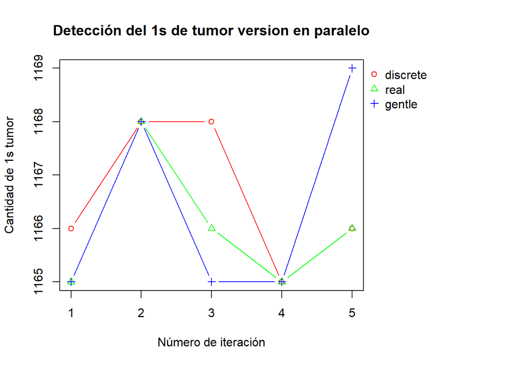

```r
# Gráfico
resultados <- data.frame("discrete"     = deteccion.no.discrete,
                         "real"     = deteccion.no.real,
                         "gentle" = deteccion.no.gentle) # Preparamos los datos

par(oma=c(0, 0, 0, 8)) # Hace espacio para la leyenda

matplot(resultados, type="b", lty = 1, lwd = 1, pch = 1:ncol(resultados),
        main = "Detección del 1s de tumor version en paralelo",
        xlab = "Número de iteración",
        ylab = "Cantidad de 1s tumor",
        col = rainbow(ncol(resultados)))
legend(par('usr')[2], par('usr')[4], legend = colnames(resultados),bty='n', xpd=NA,
       pch=1:ncol(resultados), col = rainbow(ncol(resultados))) # La leyenda
```

El mejor parece ser gentle en la quinta iteracion logra detectar el mayor numero, en los demas casos resulta tener un conteo similar a discrete y real.

2. Repita el ejercicio anterior, pero esta vez en lugar de sumar la cantidad de 1’s, promedie los errores globales cometidos en los diferentes grupos (folds). Luego grafique las 5 iteraciones para los tres algoritmos en el mismo gr´afico. ¿Se puede determinar con claridad cu´al algoritmo es el mejor?

```r
library(traineR)
library(snow)
library(caret)
##intento 1

clp <- makeCluster(5, type = "SOCK")

clusterExport(clp, "datos")
ignore <- clusterEvalQ(clp, {
      library(traineR)

      ejecutar.prediccion <- function(datos, formula, muestra,metodo, ...) {
        ttesting <- datos[muestra, ]
        taprendizaje <- datos[-muestra, ]
        modelo <- metodo(formula, data = taprendizaje, ...)
        prediccion <- predict(modelo, ttesting, type = "class")
        MC <- confusion.matrix(ttesting, prediccion)
        return(MC)
      }
      return(NULL)
})

# Constructor del cluster
numero.filas <- nrow(datos)
cantidad.validacion.cruzada <- 5
cantidad.grupos <- 10
algoritmos <- c("discrete", "real", "gentle")

deteccion.error.pot.discrete <- c()
deteccion.error.pot.real <- c()
deteccion.error.pot.gentle <- c()

# Exportamos paquetes a los procesadores
ignore <- clusterEvalQ(clp, {
  library(dplyr)
  library(traineR)
  return(NULL)
})

# Exportamos los datos y las funciones a los procesadores
clusterExport(clp, list("datos", "ejecutar.prediccion", "ejecutar.prediccion.particular"))
```

```
## Error in get(name, envir = envir): object 'ejecutar.prediccion' not found
```

```r
# Para medir el tiempo de ejecución
tiempo.paralelo <- Sys.time()

# Validación cruzada 5 veces
for(i in 1:cantidad.validacion.cruzada) {
  grupos <- createFolds(1:numero.filas, cantidad.grupos)  # Crea los 10 grupos

  error.pot.discrete <- 0
  error.pot.real <- 0
  error.pot.gentle <- 0

  # Este ciclo es el que hace validación cruzada con 10 grupos
  for(k in 1:cantidad.grupos) {
    muestra <- grupos[[k]]  # Por ser una lista requiere de doble paréntesis
    # Exportamos la muestra a los procesadores
    clusterExport(clp, "muestra")


    resultado <- clusterApply(clp, algoritmos, function(pkernels) {
      MC <- ejecutar.prediccion(datos, tipo ~ .,muestra, train.ada, iter=80, nu=1)

      # Cálculo del ERROR
      error.metodo <- (1-(sum(diag(MC)))/sum(MC))*100
      valores <- list(Tipo = pkernels, Error = error.metodo)
      return(valores)
    })

    for (j in seq_along(algoritmos)) {
      if (resultado[[j]][[1]] == "discrete")
        error.pot.discrete <- error.pot.discrete + resultado[[j]][[2]]
      else if (resultado[[j]][[1]] == "real")
        error.pot.real <- error.pot.real + resultado[[j]][[2]]
      else if (resultado[[j]][[1]] == "gentle")
        error.pot.gentle <- error.pot.gentle + resultado[[j]][[2]]
    }

  }

  deteccion.error.pot.discrete[i] <- error.pot.discrete / cantidad.grupos
  deteccion.error.pot.real[i] <- error.pot.real / cantidad.grupos
  deteccion.error.pot.gentle[i] <- error.pot.gentle / cantidad.grupos
}
stopCluster(clp)

tiempo.paralelo <- Sys.time() - tiempo.paralelo
tiempo.paralelo
```

```
## Time difference of 1.902839 mins
```

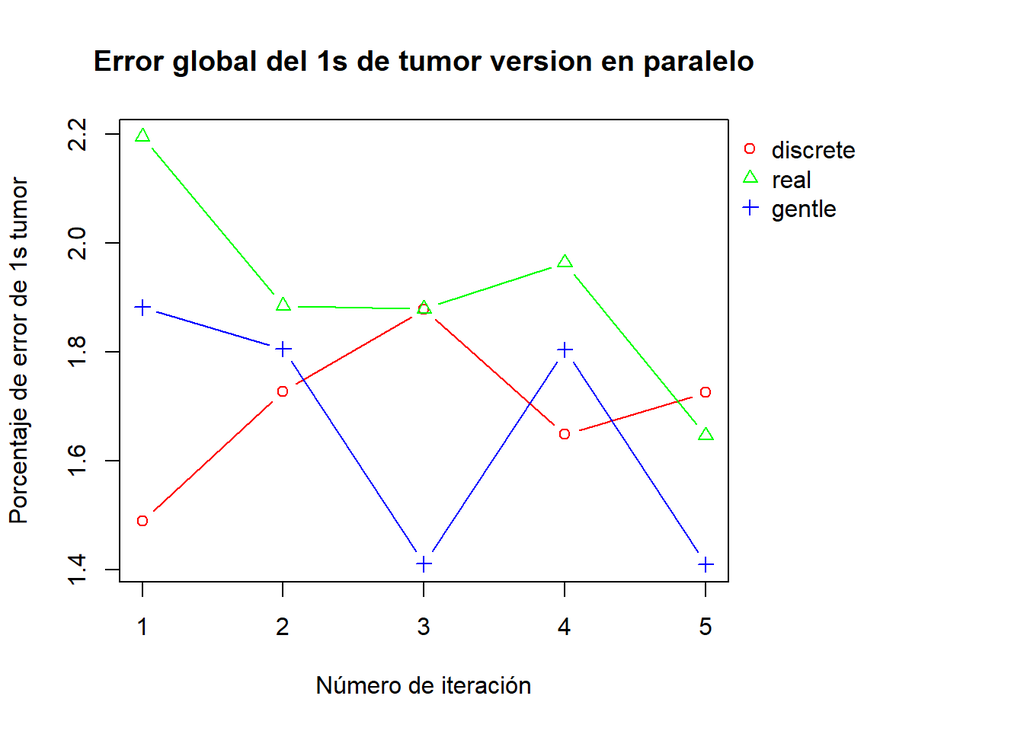

```r
# Gráfico
resultados <- data.frame("discrete"     = deteccion.error.pot.discrete,
                         "real"     = deteccion.error.pot.real,
                         "gentle" = deteccion.error.pot.gentle)

par(oma=c(0, 0, 0, 8))

matplot(resultados, type="b", lty = 1, lwd = 1, pch = 1:ncol(resultados),
        main = "Error global del 1s de tumor version en paralelo",
        xlab = "Número de iteración",
        ylab = "Porcentaje de error de 1s tumor",
        col = rainbow(ncol(resultados)))
legend(par('usr')[2], par('usr')[4], legend = colnames(resultados),bty='n', xpd=NA,
       pch=1:ncol(resultados), col = rainbow(ncol(resultados))) # La leyenda
```

3. ¿Cu´al algoritmo usar´ıa con base en la informaci´on obtenida en los dos ejercicios anteriores?

En este caso resulta complejo tomar una decision ya que a nivel de error y conteo sumatorio de 1s, se dan resultados similares en el sentido en las distintas iteraciones tienen similar variabilidad a nivel de conteo. Gentle a nivel de conteo resulta mejor, a nivel de error global y al ver que en ambos graficos presentan error y conteo similar se confirma que para el caso de ada es recomendable usar gentle.

Ejercicio 2: [30 puntos] Para esta pregunta usaremos nuevamente los datos tumores.csv.

1. El objetivo de este ejercicio es calibrar el m´etodo de kknn para esta Tabla de Datos. Aqu´ı interesa predecir en la variable tipo. Usando los paquetes snow y traineR programe en paralelo 5 Validaciones Cruzadas con 10 grupos calibrando el modelo de acuerdo con todos los tipos de algoritmos que permite train.kknn en el par´ametro kernel, estos algoritmos son: rectangular, triangular, epanechnikov, biweight, triweight, cos, inv, gaussian y optimal. Para medir la calidad de m´etodo sume la cantidad de 1’s detectados en los diferentes grupos. Luego grafique las 5 iteraciones para todos algoritmos en el mismo gr´afico. ¿Se puede determinar con claridad cu´al algoritmo es el mejor?

##Dado que en este ejercicio se busca el mejor algoritmo se usa aun un kmax=10 para limitar el tiempo de ejecucion y dejarlo para el ejercicio final

```r
library(traineR)
library(snow)
library(caret)


clp <- makeCluster(5, type = "SOCK")

clusterExport(clp, "datos")
ignore <- clusterEvalQ(clp, {
      library(traineR)

      ejecutar.prediccion <- function(datos, formula, muestra,metodo, ...) {
        ttesting <- datos[muestra, ]
        taprendizaje <- datos[-muestra, ]
        modelo <- metodo(formula, data = taprendizaje, ...)
        prediccion <- predict(modelo, ttesting, type = "class")
        MC <- confusion.matrix(ttesting, prediccion)
        return(MC)
      }
      return(NULL)
})

numero.filas <- nrow(datos)
cantidad.grupos <- 10
cantidad.validacion.cruzada <- 5
algoritmos <- c("rectangular", "triangular", "epanechnikov", "biweight", "triweight", "cos", "inv", "gaussian", "optimal")

deteccion.no.rectangular <- c()
deteccion.no.triangular <- c()
deteccion.no.epanechnikov <- c()
deteccion.no.biweight <- c()
deteccion.no.triweight <- c()
deteccion.no.cos <- c()
deteccion.no.inv <- c()
deteccion.no.gaussian <- c()
deteccion.no.optimal <- c()

# Para medir el tiempo de ejecución
tiempo.paralelo <- Sys.time()

for(i in 1:cantidad.validacion.cruzada) {
  grupos <- createFolds(1:numero.filas, cantidad.grupos)
  no.rectangular <- 0
  no.triangular <- 0
  no.epanechnikov <- 0
  no.biweight <- 0
  no.triweight <- 0
  no.cos <- 0
  no.inv <- 0
  no.gaussian <- 0
  no.optimal <- 0

  for(k in 1:cantidad.grupos) {
    muestra <- grupos[[k]]

    ### Inserta estas 1 variable en cada peón
    clusterExport(clp, "muestra")

    resultado <- clusterApply(clp, algoritmos, function(pkernels) {
      MC <- ejecutar.prediccion(datos, tipo ~ .,muestra, train.knn , kmax=10, kernel = pkernels)
      no.val <- MC[2, 2]
      valores <- list(Tipo = pkernels, Resultado = no.val)
      valores
    })

    for (j in 1:length(algoritmos)) {
      if (resultado[[j]][[1]] == "rectangular")
         no.rectangular <- no.rectangular + resultado[[j]][[2]]
      else if (resultado[[j]][[1]] == "triangular")
         no.triangular <- no.triangular + resultado[[j]][[2]]
      else if (resultado[[j]][[1]] == "epanechnikov")
         no.epanechnikov <- no.epanechnikov + resultado[[j]][[2]]
      else if (resultado[[j]][[1]] == "biweight")
         no.biweight <- no.biweight + resultado[[j]][[2]]
      else if (resultado[[j]][[1]] == "triweight")
         no.triweight <- no.triweight + resultado[[j]][[2]]
      else if (resultado[[j]][[1]] == "cos")
         no.cos <- no.cos + resultado[[j]][[2]]
      else if (resultado[[j]][[1]] == "inv")
         no.inv <- no.inv + resultado[[j]][[2]]
      else if (resultado[[j]][[1]] == "gaussian")
         no.gaussian <- no.gaussian + resultado[[j]][[2]]
      else if (resultado[[j]][[1]] == "optimal")
         no.optimal <- no.optimal + resultado[[j]][[2]]
    }
  }

  deteccion.no.rectangular[i] <- no.rectangular
  deteccion.no.triangular[i] <- no.triangular
  deteccion.no.epanechnikov[i] <- no.epanechnikov
  deteccion.no.biweight[i] <- no.biweight
  deteccion.no.triweight[i] <- no.triweight
  deteccion.no.cos[i] <- no.cos
  deteccion.no.inv[i] <- no.inv
  deteccion.no.gaussian[i] <- no.gaussian
  deteccion.no.optimal[i] <- no.optimal
}

stopCluster(clp)


tiempo.paralelo <- Sys.time() - tiempo.paralelo
tiempo.paralelo
```

```
## Time difference of 14.70931 secs
```

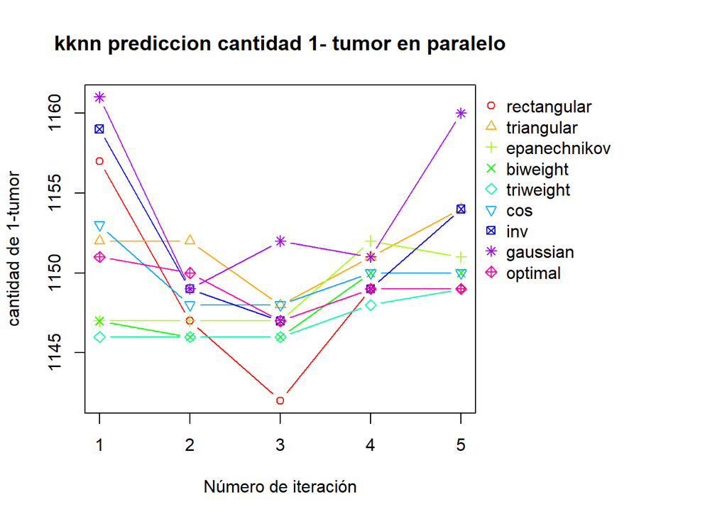

```r
resultados <- data.frame("rectangular" = deteccion.no.rectangular,
                         "triangular" = deteccion.no.triangular,
                         "epanechnikov" = deteccion.no.epanechnikov,
                         "biweight" = deteccion.no.biweight,
                         "triweight" = deteccion.no.triweight,
                         "cos" = deteccion.no.cos,
                         "inv" = deteccion.no.inv,
                         "gaussian" = deteccion.no.gaussian,
                         "optimal" = deteccion.no.optimal)

par(oma=c(0, 0, 0, 10)) # Hace espacio para la leyenda

matplot(resultados, type="b", lty = 1, lwd = 1, pch = 1:ncol(resultados),
        main = "kknn prediccion cantidad 1- tumor en paralelo",
        xlab = "Número de iteración",
        ylab = "cantidad de 1-tumor",
        col = rainbow(ncol(resultados)))
legend(par('usr')[2], par('usr')[4], legend = colnames(resultados),bty='n', xpd=NA,
       pch=1:ncol(resultados), col = rainbow(ncol(resultados))) # La leyenda
```

2. Repita el ejercicio anterior, pero esta vez en lugar de sumar la cantidad de 1’s, promedie los errores globales cometidos en los diferentes grupos (folds). Luego grafique las 5 iteraciones para todos los algoritmos en el mismo gr´afico. ¿Se puede determinar con claridad cu´al algoritmo es el mejor?

```r
library(traineR)
library(snow)
library(caret)


clp <- makeCluster(5, type = "SOCK")

clusterExport(clp, "datos")
ignore <- clusterEvalQ(clp, {
      library(traineR)

      ejecutar.prediccion <- function(datos, formula, muestra,metodo, ...) {
        ttesting <- datos[muestra, ]
        taprendizaje <- datos[-muestra, ]
        modelo <- metodo(formula, data = taprendizaje, ...)
        prediccion <- predict(modelo, ttesting, type = "class")
        MC <- confusion.matrix(ttesting, prediccion)
        return(MC)
      }
      return(NULL)
})

numero.filas <- nrow(datos)
cantidad.grupos <- 10
cantidad.validacion.cruzada <- 5
algoritmos <- c("rectangular", "triangular", "epanechnikov", "biweight", "triweight", "cos", "inv", "gaussian", "optimal")

deteccion.error.rectangular <- c()
deteccion.error.triangular <- c()
deteccion.error.epanechnikov <- c()
deteccion.error.biweight <- c()
deteccion.error.triweight <- c()
deteccion.error.cos <- c()
deteccion.error.inv <- c()
deteccion.error.gaussian <- c()
deteccion.error.optimal <- c()

# Para medir el tiempo de ejecución
tiempo.paralelo <- Sys.time()

for(i in 1:cantidad.validacion.cruzada) {
  grupos <- createFolds(1:numero.filas, cantidad.grupos)
  error.rectangular <- 0
  error.triangular <- 0
  error.epanechnikov <- 0
  error.biweight <- 0
  error.triweight <- 0
  error.cos <- 0
  error.inv <- 0
  error.gaussian <- 0
  error.optimal <- 0

  for(k in 1:cantidad.grupos) {
    muestra <- grupos[[k]]

    ### Inserta estas 1 variable en cada peón
    clusterExport(clp, "muestra")

    resultado <- clusterApply(clp, algoritmos, function(pkernels) {
      MC <- ejecutar.prediccion(datos, tipo ~ .,muestra, train.knn , kmax=10, kernel = pkernels)
      # Cálculo del ERROR
      error.metodo <- (1-(sum(diag(MC)))/sum(MC))*100
      valores <- list(Tipo = pkernels, Error = error.metodo)
      return(valores)
    })

    for (j in 1:length(algoritmos)) {
      if (resultado[[j]][[1]] == "rectangular")
         error.rectangular <- error.rectangular + resultado[[j]][[2]]
      else if (resultado[[j]][[1]] == "triangular")
         error.triangular <- error.triangular + resultado[[j]][[2]]
      else if (resultado[[j]][[1]] == "epanechnikov")
         error.epanechnikov <- error.epanechnikov + resultado[[j]][[2]]
      else if (resultado[[j]][[1]] == "biweight")
         error.biweight <- error.biweight + resultado[[j]][[2]]
      else if (resultado[[j]][[1]] == "triweight")
         error.triweight <- error.triweight + resultado[[j]][[2]]
      else if (resultado[[j]][[1]] == "cos")
         error.cos <- error.cos + resultado[[j]][[2]]
      else if (resultado[[j]][[1]] == "inv")
         error.inv <- error.inv + resultado[[j]][[2]]
      else if (resultado[[j]][[1]] == "gaussian")
         error.gaussian <- error.gaussian + resultado[[j]][[2]]
      else if (resultado[[j]][[1]] == "optimal")
         error.optimal <- error.optimal + resultado[[j]][[2]]
    }
  }

  deteccion.error.rectangular[i] <- error.rectangular / cantidad.grupos
  deteccion.error.triangular[i] <- error.triangular / cantidad.grupos
  deteccion.error.epanechnikov[i] <- error.epanechnikov / cantidad.grupos
  deteccion.error.biweight[i] <- error.biweight / cantidad.grupos
  deteccion.error.triweight[i] <- error.triweight / cantidad.grupos
  deteccion.error.cos[i] <- error.cos / cantidad.grupos
  deteccion.error.inv[i] <- error.inv / cantidad.grupos
  deteccion.error.gaussian[i] <- error.gaussian / cantidad.grupos
  deteccion.error.optimal[i] <- error.optimal / cantidad.grupos
}

stopCluster(clp)


tiempo.paralelo <- Sys.time() - tiempo.paralelo
tiempo.paralelo
```

```
## Time difference of 13.96852 secs
```

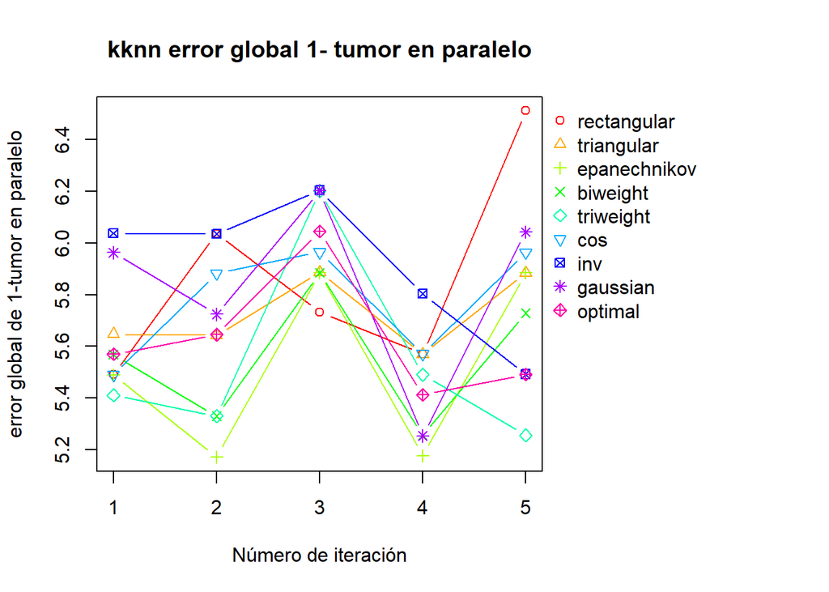

```r
resultados <- data.frame("rectangular" = deteccion.error.rectangular,
                         "triangular" = deteccion.error.triangular,
                         "epanechnikov" = deteccion.error.epanechnikov,
                         "biweight" = deteccion.error.biweight,
                         "triweight" = deteccion.error.triweight,
                         "cos" = deteccion.error.cos,
                         "inv" = deteccion.error.inv,
                         "gaussian" = deteccion.error.gaussian,
                         "optimal" = deteccion.error.optimal)

par(oma=c(0, 0, 0, 10)) # Hace espacio para la leyenda

matplot(resultados, type="b", lty = 1, lwd = 1, pch = 1:ncol(resultados),
        main = "kknn error global 1- tumor en paralelo",
        xlab = "Número de iteración",
        ylab = "error global de 1-tumor en paralelo",
        col = rainbow(ncol(resultados)))
legend(par('usr')[2], par('usr')[4], legend = colnames(resultados),bty='n', xpd=NA,
       pch=1:ncol(resultados), col = rainbow(ncol(resultados))) # La leyenda
```

3. ¿Cu´al algoritmo usar´ıa con base en la informaci´on obtenida en los dos ejercicios anteriores?

Ejercicio 3: [40 puntos] Esta pregunta tambi´en utilizan nuevamente los datos tumores.csv.

1. El objetivo de este ejercicio es comparar todos los m´etodos predictivos vistos en el curso con esta tabla de datos. Aqu´ı interesa predecir en la variable tipo, Usando los paquetes snow y traineR programe en paralelo 5 Validaciones Cruzadas con 10 grupos para los m´etodos SVM, KNN, ´Arboles, Bosques, Potenciaci´on, eXtreme Gradient Boosting, LDA, Bayes, Regresi´on Log´ıstica, ConsensoPropio y Redes Neuronales, para KNN y Potenciaci´on use los par´ametros obtenidos en las calibraciones realizadas en los ejercicios anteriores. Luego grafique las 5 iteraciones para todos los m´etodos en el mismo gr´afico. ¿Se puede determinar con claridad cu´al m´etodos es el mejor?

```r
library(caret)
library(snow)
library(MASS)
library(class)

setwd("C:/Users/rzamoram/Documents/Machine Learning/Mineria de Datos I/Clase2")
data1<-read.csv("tumores.csv",dec='.',header=T)
data1$tipo <- factor(data1$tipo,ordered = TRUE)
datos <- data1[,-1]

peones <- parallel::detectCores()
clp <- makeCluster(peones, type = "SOCK")

ejecutar.prediccion <- function(datos, formula, muestra, metodo, ...) {
  ttesting <- datos[muestra, ]
  ttraining <- datos[-muestra, ]
  #modelo <- metodo(formula, data = ttraining, ...)
  modelo <- do.call(metodo, list(formula, data = ttraining, ...))
  prediccion <- predict(modelo, ttesting, type = "class")
  MC <- confusion.matrix(ttesting, prediccion)
  return(MC)
}

# La siguiente función permite fijar parámetros específicos para cada método, lo cual es útil para usar otros parámetros que no sean los default.

ejecutar.prediccion.particular <- function(datos, formula, muestra, metodo) {
  if(metodo == "train.svm"){return(ejecutar.prediccion(datos, formula, muestra, metodo, kernel = "radial", probability = FALSE))}
  if(metodo == "train.knn"){return(ejecutar.prediccion(datos, formula, muestra, metodo, kmax = 80, type = "triweight"))}
  if(metodo == "train.bayes"){return(ejecutar.prediccion(datos, formula, muestra, metodo))}
  if(metodo == "train.rpart"){return(ejecutar.prediccion(datos, formula, muestra, metodo))}
  if(metodo == "train.randomForest"){return(ejecutar.prediccion(datos, formula, muestra, metodo, importance = TRUE))}
  if(metodo == "train.ada"){return(ejecutar.prediccion(datos, formula, muestra, metodo, iter = 50, nu = 1, type = "gentle"))}
  if(metodo == "train.nnet"){return(ejecutar.prediccion(datos, formula, muestra, metodo, size = 5, rang = 0.1, decay = 5e-04, maxit = 100, trace = FALSE))}
  if(metodo == "train.xgboost"){return(ejecutar.prediccion(datos, formula, muestra, metodo, nrounds = 79, print_every_n = 10, maximize = F , eval_metric = "error"))}
  if(metodo == "train.glm"){return(ejecutar.prediccion(datos, formula, muestra, metodo))}
  if(metodo == "train.neuralnet"){return(ejecutar.prediccion(datos, formula, muestra, metodo, hidden = c(8,6,4), linear.output = FALSE, threshold = 0.5, stepmax = 1e+06))}
}

# Constructor del cluster
numero.filas <- nrow(datos)
cantidad.validacion.cruzada <- 5
cantidad.grupos <- 10
metodos <- c("train.svm", "train.knn", "train.bayes", "train.rpart", "train.randomForest", "train.ada", "train.nnet", "train.xgboost", "train.neuralnet", "train.glm")

deteccion.no.svm <- c()
deteccion.no.knn <- c()
deteccion.no.bayes <- c()
deteccion.no.arbol <- c()
deteccion.no.bosque <- c()
deteccion.no.potenciacion <- c()
deteccion.no.red <- c()
deteccion.no.xgboost <- c()
deteccion.no.red.neu <- c()
deteccion.no.glm <- c()

ignore <- clusterEvalQ(clp, {
  library(dplyr)
  library(traineR)

  return(NULL)
})

# Exportamos los datos y las funciones a los procesadores
clusterExport(clp, list("datos", "ejecutar.prediccion", "ejecutar.prediccion.particular"))

tiempo.paralelo <- Sys.time()

# Validación cruzada 5 veces
for(i in 1:cantidad.validacion.cruzada) {
  grupos <- createFolds(1:numero.filas, cantidad.grupos)  # Crea los 10 grupos
  no.svm <- 0
  no.knn <- 0
  no.bayes <- 0
  no.arbol <- 0
  no.bosque <- 0
  no.potenciacion <- 0
  no.red <- 0
  no.xg  <- 0
  no.red.neu <- 0
  no.glm <- 0

  for(k in 1:cantidad.grupos) {
    muestra <- grupos[[k]]
    clusterExport(clp, "muestra")

    resultado <- clusterApply(clp, metodos, function(metodo) {
      MC <- ejecutar.prediccion.particular(datos = datos, formula = tipo~., muestra = muestra, metodo = metodo)
      no.val <- MC[2, 2]
      valores <- list(Tipo = metodo, Resultado = no.val)
      return(valores)
    })

    for (j in seq_along(metodos)) {
      if (resultado[[j]][[1]] == "train.svm")
        no.svm <- no.svm + resultado[[j]][[2]]
      else if (resultado[[j]][[1]] == "train.knn")
        no.knn <- no.knn + resultado[[j]][[2]]
      else if (resultado[[j]][[1]] == "train.bayes")
        no.bayes <- no.bayes + resultado[[j]][[2]]
      else if (resultado[[j]][[1]] == "train.rpart")
        no.arbol <- no.arbol + resultado[[j]][[2]]
      else if (resultado[[j]][[1]] == "train.randomForest")
        no.bosque <- no.bosque + resultado[[j]][[2]]
      else if (resultado[[j]][[1]] == "train.ada")
        no.potenciacion <- no.potenciacion + resultado[[j]][[2]]
      else if (resultado[[j]][[1]] == "train.nnet")
        no.red <- no.red + resultado[[j]][[2]]
      else if (resultado[[j]][[1]] == "train.xgboost")
        no.xg <- no.xg + resultado[[j]][[2]]
      else if (resultado[[j]][[1]] == "train.neuralnet")
        no.red.neu <- no.red.neu + resultado[[j]][[2]]
      else if (resultado[[j]][[1]] == "train.glm")
        no.glm <- no.glm + resultado[[j]][[2]]
    }

  }
  deteccion.no.svm[i] <- no.svm
  deteccion.no.knn[i] <- no.knn
  deteccion.no.bayes[i] <- no.bayes
  deteccion.no.arbol[i] <- no.arbol
  deteccion.no.bosque[i] <- no.bosque
  deteccion.no.potenciacion[i] <- no.potenciacion
  deteccion.no.red[i] <- no.red
  deteccion.no.xgboost[i] <- no.xg
  deteccion.no.red.neu[i] <- no.red.neu
  deteccion.no.glm[i] <- no.glm
}

stopCluster(clp)

tiempo.paralelo <- Sys.time() - tiempo.paralelo
tiempo.paralelo
```

```
## Time difference of 28.38718 mins
```

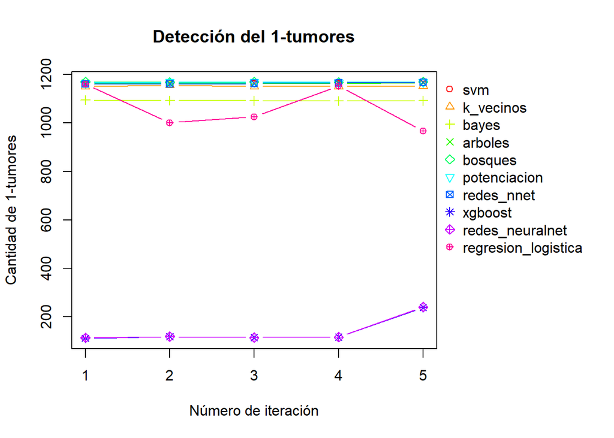

```r
resultados <- data.frame("svm" = deteccion.no.svm,
                         "k_vecinos" = deteccion.no.knn,
                         "bayes" = deteccion.no.bayes,
                         "arboles" = deteccion.no.arbol,
                         "bosques" = deteccion.no.bosque,
                         "potenciacion" = deteccion.no.potenciacion,
                         "redes_nnet" = deteccion.no.red,
                         "xgboost" = deteccion.no.xgboost,
                         "redes_neuralnet" = deteccion.no.red.neu,
                         "regresion_logistica" = deteccion.no.glm)

par(oma=c(0, 0, 0, 8)) # Hace espacio para la leyenda
matplot(resultados, type="b", lty = 1, lwd = 1, pch = 1:ncol(resultados),
        main = "Detección del 1-tumores",
        xlab = "Número de iteración",
        ylab = "Cantidad de 1-tumores",
        col = rainbow(ncol(resultados)))
legend(par('usr')[2], par('usr')[4], legend = colnames(resultados),bty='n', xpd=NA,
       pch=1:ncol(resultados), col = rainbow(ncol(resultados))) # La leyenda
```

En este caso inicial la cantidad mejor detectada de 1-tumores es dificil de apreciar pero parece ser redes(nnet), aunque bosques aleatorios tambien parece tener una estimacion muy acertada.

2. Repita el ejercicio anterior, pero en lugar de sumar la cantidad de 1’s, promedie los errores globales cometidos en los diferentes grupos (folds). Luego grafique las 5 iteraciones para todos los m´etodos vistos en el curso en el mismo gr´afico. ¿Se puede determinar con claridad cu´al algoritmo es el mejor?

```r
library(snow)
library(caret)

peones <- parallel::detectCores()
clp <- makeCluster(peones, type = "SOCK")

ejecutar.prediccion <- function(datos, formula, muestra, metodo, ...) {
  ttesting <- datos[muestra, ]
  ttraining <- datos[-muestra, ]
  #modelo <- metodo(formula, data = ttraining, ...)
  modelo <- do.call(metodo, list(formula, data = ttraining, ...))
  prediccion <- predict(modelo, ttesting, type = "class")
  MC <- confusion.matrix(ttesting, prediccion)
  return(MC)
}

# La siguiente función permite fijar parámetros específicos para cada método, lo cual es útil para usar otros parámetros que no sean los default.

ejecutar.prediccion.particular <- function(datos, formula, muestra, metodo) {
  if(metodo == "train.svm"){return(ejecutar.prediccion(datos, formula, muestra, metodo, kernel = "radial", probability = FALSE))}
  if(metodo == "train.knn"){return(ejecutar.prediccion(datos, formula, muestra, metodo,  kmax = 100, kernel = "triweight"))}
  if(metodo == "train.bayes"){return(ejecutar.prediccion(datos, formula, muestra, metodo))}
  if(metodo == "train.rpart"){return(ejecutar.prediccion(datos, formula, muestra, metodo))}
  if(metodo == "train.randomForest"){return(ejecutar.prediccion(datos, formula, muestra, metodo, importance = TRUE))}
  if(metodo == "train.ada"){return(ejecutar.prediccion(datos, formula, muestra, metodo, iter = 100, nu = 1, type = "gentle"))}
  if(metodo == "train.nnet"){return(ejecutar.prediccion(datos, formula, muestra, metodo, size = 5, rang = 0.1, decay = 5e-04, maxit = 100, trace = FALSE))}
  if(metodo == "train.xgboost"){return(ejecutar.prediccion(datos, formula, muestra, metodo, nrounds = 79, print_every_n = 10, maximize = F , eval_metric = "error"))}
  if(metodo == "train.glm"){return(ejecutar.prediccion(datos, formula, muestra, metodo))}
  if(metodo == "train.neuralnet"){return(ejecutar.prediccion(datos, formula, muestra, metodo,hidden = c(8,6,4), linear.output = FALSE, threshold = 0.5, stepmax = 1e+06))}
}


# Constructor del cluster
numero.filas <- nrow(datos)
cantidad.validacion.cruzada <- 5
cantidad.grupos <- 10
metodos <- c("train.svm", "train.knn", "train.bayes", "train.rpart", "train.randomForest", "train.ada", "train.nnet",
             "train.xgboost", "train.neuralnet", "train.glm")

deteccion.error.svm <- c()
deteccion.error.knn <- c()
deteccion.error.bayes <- c()
deteccion.error.arbol <- c()
deteccion.error.bosque <- c()
deteccion.error.potenciacion <- c()
deteccion.error.red <- c()
deteccion.error.xgboost <- c()
deteccion.error.red.neu <- c()
deteccion.error.glm <- c()

# Exportamos paquetes a los procesadores
ignore <- clusterEvalQ(clp, {
  library(dplyr)
  library(traineR)
  return(NULL)
})

# Exportamos los datos y las funciones a los procesadores
clusterExport(clp, list("datos", "ejecutar.prediccion", "ejecutar.prediccion.particular"))

# Para medir el tiempo de ejecución
tiempo.paralelo <- Sys.time()

# Validación cruzada 5 veces
for(i in 1:cantidad.validacion.cruzada) {
  grupos <- createFolds(1:numero.filas, cantidad.grupos)  # Crea los 10 grupos
  error.svm <- 0
  error.knn <- 0
  error.bayes <- 0
  error.arbol <- 0
  error.bosque <- 0
  error.potenciacion <- 0
  error.red <- 0
  error.xg  <- 0
  error.red.neu <- 0
  error.glm <- 0

  # Este ciclo es el que hace validación cruzada con 10 grupos
  for(k in 1:cantidad.grupos) {
    muestra <- grupos[[k]]  # Por ser una lista requiere de doble paréntesis
    # Exportamos la muestra a los procesadores
    clusterExport(clp, "muestra")

    resultado <- clusterApply(clp, metodos, function(metodo) {
      MC <- ejecutar.prediccion.particular(datos = datos, formula = tipo~., muestra = muestra, metodo = metodo)
      # Cálculo del ERROR
      error.metodo <- (1-(sum(diag(MC)))/sum(MC))*100
      valores <- list(Tipo = metodo, Error = error.metodo)
      return(valores)
    })

    for (j in seq_along(metodos)) {
      if (resultado[[j]][[1]] == "train.svm")
        error.svm <- error.svm + resultado[[j]][[2]]
      else if (resultado[[j]][[1]] == "train.knn")
        error.knn <- error.knn + resultado[[j]][[2]]
      else if (resultado[[j]][[1]] == "train.bayes")
        error.bayes <- error.bayes + resultado[[j]][[2]]
      else if (resultado[[j]][[1]] == "train.rpart")
        error.arbol <- error.arbol + resultado[[j]][[2]]
      else if (resultado[[j]][[1]] == "train.randomForest")
        error.bosque <- error.bosque + resultado[[j]][[2]]
      else if (resultado[[j]][[1]] == "train.ada")
        error.potenciacion <- error.potenciacion + resultado[[j]][[2]]
      else if (resultado[[j]][[1]] == "train.nnet")
        error.red <- error.red + resultado[[j]][[2]]
      else if (resultado[[j]][[1]] == "train.xgboost")
        error.xg <- error.xg + resultado[[j]][[2]]
      else if (resultado[[j]][[1]] == "train.neuralnet")
        error.red.neu <- error.red.neu + resultado[[j]][[2]]
      else if (resultado[[j]][[1]] == "train.glm")
        error.glm <- error.glm + resultado[[j]][[2]]
    }

  }
  deteccion.error.svm[i] <- error.svm / cantidad.grupos
  deteccion.error.knn[i] <- error.knn / cantidad.grupos
  deteccion.error.bayes[i] <- error.bayes / cantidad.grupos
  deteccion.error.arbol[i] <- error.arbol / cantidad.grupos
  deteccion.error.bosque[i] <- error.bosque / cantidad.grupos
  deteccion.error.potenciacion[i] <- error.potenciacion / cantidad.grupos
  deteccion.error.red[i] <- error.red / cantidad.grupos
  deteccion.error.xgboost[i] <- error.xg / cantidad.grupos
  deteccion.error.red.neu[i] <- error.red.neu / cantidad.grupos
  deteccion.error.glm[i] <- error.glm / cantidad.grupos
}
stopCluster(clp)

tiempo.paralelo <- Sys.time() - tiempo.paralelo
tiempo.paralelo
```

```
## Time difference of 1.010026 hours
```

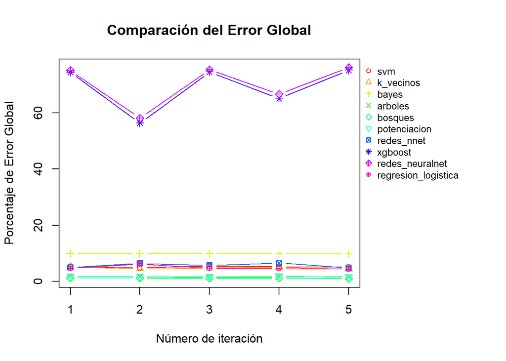

```r
resultados <- data.frame("svm" = deteccion.error.svm,
                         "k_vecinos" = deteccion.error.knn,
                         "bayes" = deteccion.error.bayes,
                         "arboles" = deteccion.error.arbol,
                         "bosques" = deteccion.error.bosque,
                         "potenciacion" = deteccion.error.potenciacion,
                         "redes_nnet" = deteccion.error.red,
                         "xgboost" = deteccion.error.xgboost,
                         "redes_neuralnet" = deteccion.error.red.neu,
                         "regresion_logistica" = deteccion.error.glm)

par(oma=c(0, 0, 0, 8)) # Hace espacio para la leyenda
matplot(resultados, type="b", lty = 1, lwd = 1, pch = 1:ncol(resultados),
        main = "Comparación del Error Global",
        xlab = "Número de iteración",
        ylab = "Porcentaje de Error Global",
        col = rainbow(ncol(resultados)))
legend(par('usr')[2], par('usr')[4], legend = colnames(resultados),bty='n', xpd=NA, cex = 0.8,
       pch=1:ncol(resultados), col = rainbow(ncol(resultados))) # La leyenda
```

3. ¿Cu´al m´etodo usar´ıa con base en la informaci´on obtenida en los dos ejercicios anteriores?